# Risk Factor Analysis

## Outcome Variable

**Outcome Variable:** wasted

## Predictor Variables

**Intervention Variable:** predfeed36

**Adjustment Set:**

- arm
- sex
- month
- brthmon
- W_mage
- meducyrs
- feducyrs
- hhwealth_quart
- hfoodsec
- W_mhtcm
- W_mwtkg
- W_mbmi
- vagbrth
- W_gagebrth
- W_birthwt
- W_birthlen
- W_nrooms
- W_nchldlt5
- W_parity
- impfloor
- impsan
- safeh20
- delta_W_mage
- delta_meducyrs
- delta_feducyrs
- delta_hhwealth_quart
- delta_hfoodsec
- delta_W_mhtcm
- delta_W_mwtkg
- delta_W_mbmi
- delta_vagbrth
- delta_W_gagebrth
- delta_W_birthwt
- delta_W_birthlen
- delta_W_nrooms
- delta_W_nchldlt5
- delta_W_parity
- delta_impfloor
- delta_impsan
- delta_safeh20

## Stratifying Variables

The analysis was stratified on these variable(s):

- agecat
- studyid
- country

## Data Summary

| agecat | studyid | country | predfeed36 | wasted | n_cell | n |
| --- | --- | --- | --- | --- | --- | --- |
| Birth | EE | PAKISTAN | 1 | 0 | 2 | 6 |
| Birth | EE | PAKISTAN | 1 | 1 | 0 | 6 |
| Birth | EE | PAKISTAN | 0 | 0 | 3 | 6 |
| Birth | EE | PAKISTAN | 0 | 1 | 1 | 6 |
| Birth | GMS-Nepal | NEPAL | 1 | 0 | 320 | 491 |
| Birth | GMS-Nepal | NEPAL | 1 | 1 | 76 | 491 |
| Birth | GMS-Nepal | NEPAL | 0 | 0 | 77 | 491 |
| Birth | GMS-Nepal | NEPAL | 0 | 1 | 18 | 491 |
| Birth | JiVitA-3 | BANGLADESH | 1 | 0 | 5983 | 8619 |
| Birth | JiVitA-3 | BANGLADESH | 1 | 1 | 763 | 8619 |
| Birth | JiVitA-3 | BANGLADESH | 0 | 0 | 1680 | 8619 |
| Birth | JiVitA-3 | BANGLADESH | 0 | 1 | 193 | 8619 |
| Birth | JiVitA-4 | BANGLADESH | 1 | 0 | 1540 | 2128 |
| Birth | JiVitA-4 | BANGLADESH | 1 | 1 | 174 | 2128 |
| Birth | JiVitA-4 | BANGLADESH | 0 | 0 | 367 | 2128 |
| Birth | JiVitA-4 | BANGLADESH | 0 | 1 | 47 | 2128 |
| Birth | MAL-ED | BANGLADESH | 1 | 0 | 59 | 208 |
| Birth | MAL-ED | BANGLADESH | 1 | 1 | 10 | 208 |
| Birth | MAL-ED | BANGLADESH | 0 | 0 | 115 | 208 |
| Birth | MAL-ED | BANGLADESH | 0 | 1 | 24 | 208 |
| Birth | MAL-ED | BRAZIL | 1 | 0 | 7 | 62 |
| Birth | MAL-ED | BRAZIL | 1 | 1 | 0 | 62 |
| Birth | MAL-ED | BRAZIL | 0 | 0 | 53 | 62 |
| Birth | MAL-ED | BRAZIL | 0 | 1 | 2 | 62 |
| Birth | MAL-ED | INDIA | 1 | 0 | 4 | 40 |
| Birth | MAL-ED | INDIA | 1 | 1 | 0 | 40 |
| Birth | MAL-ED | INDIA | 0 | 0 | 31 | 40 |
| Birth | MAL-ED | INDIA | 0 | 1 | 5 | 40 |
| Birth | MAL-ED | NEPAL | 1 | 0 | 0 | 25 |
| Birth | MAL-ED | NEPAL | 1 | 1 | 1 | 25 |

[output cut: 114 more lines]

The following strata were considered:

- agecat: 24 months, studyid: EE, country: PAKISTAN
- agecat: 24 months, studyid: GMS-Nepal, country: NEPAL
- agecat: 24 months, studyid: JiVitA-3, country: BANGLADESH
- agecat: 24 months, studyid: JiVitA-4, country: BANGLADESH
- agecat: 24 months, studyid: LCNI-5, country: MALAWI
- agecat: 24 months, studyid: MAL-ED, country: BANGLADESH
- agecat: 24 months, studyid: MAL-ED, country: BRAZIL
- agecat: 24 months, studyid: MAL-ED, country: INDIA
- agecat: 24 months, studyid: MAL-ED, country: NEPAL
- agecat: 24 months, studyid: MAL-ED, country: PERU
- agecat: 24 months, studyid: MAL-ED, country: SOUTH AFRICA
- agecat: 24 months, studyid: MAL-ED, country: TANZANIA, UNITED REPUBLIC OF
- agecat: 6 months, studyid: EE, country: PAKISTAN
- agecat: 6 months, studyid: GMS-Nepal, country: NEPAL
- agecat: 6 months, studyid: JiVitA-3, country: BANGLADESH
- agecat: 6 months, studyid: JiVitA-4, country: BANGLADESH
- agecat: 6 months, studyid: LCNI-5, country: MALAWI
- agecat: 6 months, studyid: MAL-ED, country: BANGLADESH
- agecat: 6 months, studyid: MAL-ED, country: BRAZIL
- agecat: 6 months, studyid: MAL-ED, country: INDIA
- agecat: 6 months, studyid: MAL-ED, country: NEPAL
- agecat: 6 months, studyid: MAL-ED, country: PERU
- agecat: 6 months, studyid: MAL-ED, country: SOUTH AFRICA
- agecat: 6 months, studyid: MAL-ED, country: TANZANIA, UNITED REPUBLIC OF
- agecat: 6 months, studyid: SAS-FoodSuppl, country: INDIA
- agecat: Birth, studyid: EE, country: PAKISTAN
- agecat: Birth, studyid: GMS-Nepal, country: NEPAL
- agecat: Birth, studyid: JiVitA-3, country: BANGLADESH
- agecat: Birth, studyid: JiVitA-4, country: BANGLADESH
- agecat: Birth, studyid: MAL-ED, country: BANGLADESH
- agecat: Birth, studyid: MAL-ED, country: BRAZIL
- agecat: Birth, studyid: MAL-ED, country: INDIA
- agecat: Birth, studyid: MAL-ED, country: NEPAL
- agecat: Birth, studyid: MAL-ED, country: PERU
- agecat: Birth, studyid: MAL-ED, country: SOUTH AFRICA
- agecat: Birth, studyid: MAL-ED, country: TANZANIA, UNITED REPUBLIC OF

### Dropped Strata

Some strata were dropped due to rare outcomes:

- agecat: Birth, studyid: EE, country: PAKISTAN
- agecat: Birth, studyid: MAL-ED, country: BRAZIL
- agecat: Birth, studyid: MAL-ED, country: INDIA
- agecat: Birth, studyid: MAL-ED, country: NEPAL
- agecat: Birth, studyid: MAL-ED, country: PERU
- agecat: Birth, studyid: MAL-ED, country: SOUTH AFRICA
- agecat: Birth, studyid: MAL-ED, country: TANZANIA, UNITED REPUBLIC OF
- agecat: 6 months, studyid: EE, country: PAKISTAN
- agecat: 6 months, studyid: LCNI-5, country: MALAWI
- agecat: 6 months, studyid: MAL-ED, country: BANGLADESH
- agecat: 6 months, studyid: MAL-ED, country: BRAZIL
- agecat: 6 months, studyid: MAL-ED, country: INDIA
- agecat: 6 months, studyid: MAL-ED, country: NEPAL
- agecat: 6 months, studyid: MAL-ED, country: PERU
- agecat: 6 months, studyid: MAL-ED, country: SOUTH AFRICA
- agecat: 6 months, studyid: MAL-ED, country: TANZANIA, UNITED REPUBLIC OF
- agecat: 6 months, studyid: SAS-FoodSuppl, country: INDIA
- agecat: 24 months, studyid: EE, country: PAKISTAN
- agecat: 24 months, studyid: LCNI-5, country: MALAWI
- agecat: 24 months, studyid: MAL-ED, country: BRAZIL
- agecat: 24 months, studyid: MAL-ED, country: INDIA
- agecat: 24 months, studyid: MAL-ED, country: NEPAL
- agecat: 24 months, studyid: MAL-ED, country: PERU
- agecat: 24 months, studyid: MAL-ED, country: SOUTH AFRICA
- agecat: 24 months, studyid: MAL-ED, country: TANZANIA, UNITED REPUBLIC OF

## Methods Detail

We’re interested in the causal parameters $E[Y_a]$ for all values of $a \in \mathcal{A}$. These parameters represent the mean outcome if, possibly contrary to fact, we intervened to set all units to have $A=a$. Under the randomization and positivity assumptions, these are identified by the statistical parameters $\psi_a=E_W[E_{Y|A,W}(Y|A=a,W)]$. In addition, we’re interested in the mean of $Y$, $E[Y]$ under no intervention (the observed mean). We will estimate these parameters by using SuperLearner to fit the relevant likelihood factors – $E_{Y|A,W}(Y|A=a,W)$ and $p(A=a|W)$, and then updating our likelihood fit using a joint TMLE.

For unadjusted analyses ($W=\{\}$), initial likelihoods were estimated using Lrnr_glm to estimate the simple $E(Y|A)$ and Lrnr_mean to estimate $p(A)$. For adjusted analyses, a small library containing Lrnr_glmnet, Lrnr_xgboost, and Lrnr_mean was used.

Having estimated these parameters, we will then use the delta method to estimate relative risks and attributable risks relative to a prespecified baseline level of $A$.

# Results Detail

## Results Plots

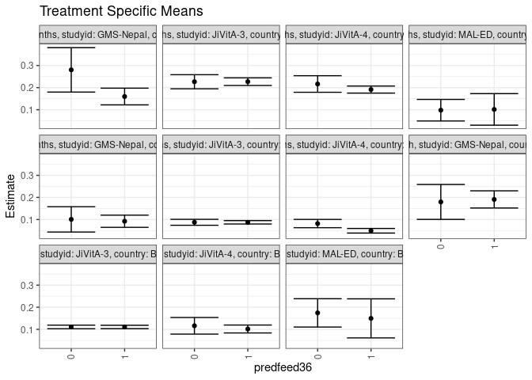

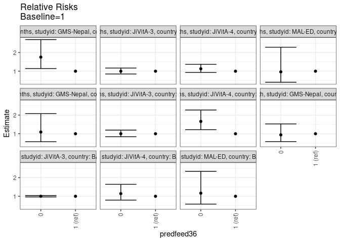

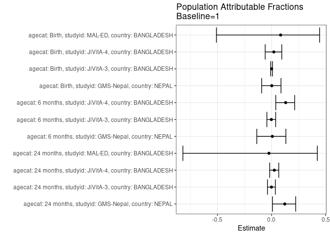

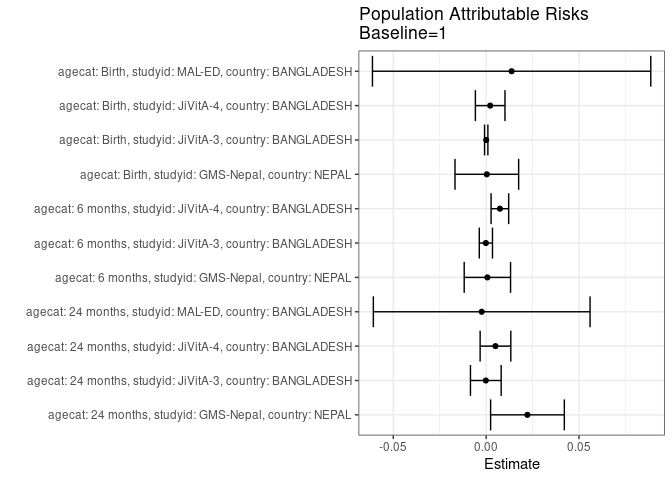

## Results Table

### Parameter: TSM

| agecat | studyid | country | intervention_level | baseline_level | estimate | ci_lower | ci_upper |
| --- | --- | --- | --- | --- | --- | --- | --- |
| Birth | GMS-Nepal | NEPAL | 1 | NA | 0.1910788 | 0.1522263 | 0.2299313 |
| Birth | GMS-Nepal | NEPAL | 0 | NA | 0.1797093 | 0.1006688 | 0.2587498 |
| Birth | JiVitA-3 | BANGLADESH | 1 | NA | 0.1108749 | 0.1032405 | 0.1185094 |
| Birth | JiVitA-3 | BANGLADESH | 0 | NA | 0.1110162 | 0.1029366 | 0.1190957 |
| Birth | JiVitA-4 | BANGLADESH | 1 | NA | 0.1016805 | 0.0837296 | 0.1196315 |
| Birth | JiVitA-4 | BANGLADESH | 0 | NA | 0.1161418 | 0.0784890 | 0.1537946 |
| Birth | MAL-ED | BANGLADESH | 1 | NA | 0.1497440 | 0.0612854 | 0.2382025 |
| Birth | MAL-ED | BANGLADESH | 0 | NA | 0.1745666 | 0.1104712 | 0.2386620 |
| 6 months | GMS-Nepal | NEPAL | 1 | NA | 0.0923091 | 0.0647415 | 0.1198767 |
| 6 months | GMS-Nepal | NEPAL | 0 | NA | 0.1007847 | 0.0433973 | 0.1581721 |
| 6 months | JiVitA-3 | BANGLADESH | 1 | NA | 0.0874273 | 0.0796923 | 0.0951623 |
| 6 months | JiVitA-3 | BANGLADESH | 0 | NA | 0.0875193 | 0.0740392 | 0.1009995 |
| 6 months | JiVitA-4 | BANGLADESH | 1 | NA | 0.0491934 | 0.0387818 | 0.0596051 |
| 6 months | JiVitA-4 | BANGLADESH | 0 | NA | 0.0817352 | 0.0629827 | 0.1004877 |
| 24 months | GMS-Nepal | NEPAL | 1 | NA | 0.1597672 | 0.1219614 | 0.1975730 |
| 24 months | GMS-Nepal | NEPAL | 0 | NA | 0.2803723 | 0.1799116 | 0.3808330 |
| 24 months | JiVitA-3 | BANGLADESH | 1 | NA | 0.2269537 | 0.2096941 | 0.2442132 |
| 24 months | JiVitA-3 | BANGLADESH | 0 | NA | 0.2265851 | 0.1947240 | 0.2584461 |
| 24 months | JiVitA-4 | BANGLADESH | 1 | NA | 0.1912569 | 0.1752530 | 0.2072609 |
| 24 months | JiVitA-4 | BANGLADESH | 0 | NA | 0.2163972 | 0.1788724 | 0.2539221 |
| 24 months | MAL-ED | BANGLADESH | 1 | NA | 0.1014493 | 0.0300414 | 0.1728571 |
| 24 months | MAL-ED | BANGLADESH | 0 | NA | 0.0979021 | 0.0490785 | 0.1467257 |

### Parameter: E(Y)

| agecat | studyid | country | intervention_level | baseline_level | estimate | ci_lower | ci_upper |
| --- | --- | --- | --- | --- | --- | --- | --- |
| Birth | GMS-Nepal | NEPAL | NA | NA | 0.1914460 | 0.1566101 | 0.2262820 |
| Birth | JiVitA-3 | BANGLADESH | NA | NA | 0.1109177 | 0.1033745 | 0.1184610 |
| Birth | JiVitA-4 | BANGLADESH | NA | NA | 0.1038534 | 0.0874500 | 0.1202568 |
| Birth | MAL-ED | BANGLADESH | NA | NA | 0.1634615 | 0.1130867 | 0.2138364 |
| 6 months | GMS-Nepal | NEPAL | NA | NA | 0.0929791 | 0.0681617 | 0.1177965 |
| 6 months | JiVitA-3 | BANGLADESH | NA | NA | 0.0872876 | 0.0805483 | 0.0940269 |
| 6 months | JiVitA-4 | BANGLADESH | NA | NA | 0.0565903 | 0.0475372 | 0.0656433 |
| 24 months | GMS-Nepal | NEPAL | NA | NA | 0.1820225 | 0.1461311 | 0.2179138 |
| 24 months | JiVitA-3 | BANGLADESH | NA | NA | 0.2267779 | 0.2114523 | 0.2421034 |
| 24 months | JiVitA-4 | BANGLADESH | NA | NA | 0.1962825 | 0.1816413 | 0.2109237 |
| 24 months | MAL-ED | BANGLADESH | NA | NA | 0.0990566 | 0.0587480 | 0.1393652 |

### Parameter: RR

| agecat | studyid | country | intervention_level | baseline_level | estimate | ci_lower | ci_upper |
| --- | --- | --- | --- | --- | --- | --- | --- |
| Birth | GMS-Nepal | NEPAL | 1 | 1 | 1.0000000 | 1.0000000 | 1.000000 |
| Birth | GMS-Nepal | NEPAL | 0 | 1 | 0.9404985 | 0.5791950 | 1.527184 |
| Birth | JiVitA-3 | BANGLADESH | 1 | 1 | 1.0000000 | 1.0000000 | 1.000000 |
| Birth | JiVitA-3 | BANGLADESH | 0 | 1 | 1.0012739 | 0.9644437 | 1.039511 |
| Birth | JiVitA-4 | BANGLADESH | 1 | 1 | 1.0000000 | 1.0000000 | 1.000000 |
| Birth | JiVitA-4 | BANGLADESH | 0 | 1 | 1.1422224 | 0.7943924 | 1.642352 |
| Birth | MAL-ED | BANGLADESH | 1 | 1 | 1.0000000 | 1.0000000 | 1.000000 |
| Birth | MAL-ED | BANGLADESH | 0 | 1 | 1.1657671 | 0.5804534 | 2.341296 |
| 6 months | GMS-Nepal | NEPAL | 1 | 1 | 1.0000000 | 1.0000000 | 1.000000 |
| 6 months | GMS-Nepal | NEPAL | 0 | 1 | 1.0918174 | 0.5733818 | 2.079008 |
| 6 months | JiVitA-3 | BANGLADESH | 1 | 1 | 1.0000000 | 1.0000000 | 1.000000 |
| 6 months | JiVitA-3 | BANGLADESH | 0 | 1 | 1.0010532 | 0.8386979 | 1.194837 |
| 6 months | JiVitA-4 | BANGLADESH | 1 | 1 | 1.0000000 | 1.0000000 | 1.000000 |
| 6 months | JiVitA-4 | BANGLADESH | 0 | 1 | 1.6615060 | 1.2155052 | 2.271156 |
| 24 months | GMS-Nepal | NEPAL | 1 | 1 | 1.0000000 | 1.0000000 | 1.000000 |
| 24 months | GMS-Nepal | NEPAL | 0 | 1 | 1.7548802 | 1.1426068 | 2.695244 |
| 24 months | JiVitA-3 | BANGLADESH | 1 | 1 | 1.0000000 | 1.0000000 | 1.000000 |
| 24 months | JiVitA-3 | BANGLADESH | 0 | 1 | 0.9983759 | 0.8523608 | 1.169404 |
| 24 months | JiVitA-4 | BANGLADESH | 1 | 1 | 1.0000000 | 1.0000000 | 1.000000 |
| 24 months | JiVitA-4 | BANGLADESH | 0 | 1 | 1.1314478 | 0.9352735 | 1.368770 |
| 24 months | MAL-ED | BANGLADESH | 1 | 1 | 1.0000000 | 1.0000000 | 1.000000 |
| 24 months | MAL-ED | BANGLADESH | 0 | 1 | 0.9650350 | 0.4072906 | 2.286555 |

### Parameter: PAR

| agecat | studyid | country | intervention_level | baseline_level | estimate | ci_lower | ci_upper |
| --- | --- | --- | --- | --- | --- | --- | --- |
| Birth | GMS-Nepal | NEPAL | 1 | NA | 0.0003672 | -0.0167679 | 0.0175024 |
| Birth | JiVitA-3 | BANGLADESH | 1 | NA | 0.0000428 | -0.0008580 | 0.0009437 |
| Birth | JiVitA-4 | BANGLADESH | 1 | NA | 0.0021729 | -0.0057953 | 0.0101410 |
| Birth | MAL-ED | BANGLADESH | 1 | NA | 0.0137176 | -0.0612199 | 0.0886550 |
| 6 months | GMS-Nepal | NEPAL | 1 | NA | 0.0006700 | -0.0118103 | 0.0131503 |
| 6 months | JiVitA-3 | BANGLADESH | 1 | NA | -0.0001396 | -0.0036940 | 0.0034148 |
| 6 months | JiVitA-4 | BANGLADESH | 1 | NA | 0.0073968 | 0.0026616 | 0.0121321 |
| 24 months | GMS-Nepal | NEPAL | 1 | NA | 0.0222553 | 0.0024064 | 0.0421042 |
| 24 months | JiVitA-3 | BANGLADESH | 1 | NA | -0.0001758 | -0.0084435 | 0.0080919 |
| 24 months | JiVitA-4 | BANGLADESH | 1 | NA | 0.0050256 | -0.0032341 | 0.0132853 |
| 24 months | MAL-ED | BANGLADESH | 1 | NA | -0.0023927 | -0.0607420 | 0.0559567 |

### Parameter: PAF

| agecat | studyid | country | intervention_level | baseline_level | estimate | ci_lower | ci_upper |
| --- | --- | --- | --- | --- | --- | --- | --- |
| Birth | GMS-Nepal | NEPAL | 1 | NA | 0.0019183 | -0.0917230 | 0.0875275 |
| Birth | JiVitA-3 | BANGLADESH | 1 | NA | 0.0003859 | -0.0077700 | 0.0084759 |
| Birth | JiVitA-4 | BANGLADESH | 1 | NA | 0.0209223 | -0.0588245 | 0.0946629 |
| Birth | MAL-ED | BANGLADESH | 1 | NA | 0.0839192 | -0.5103701 | 0.4443720 |
| 6 months | GMS-Nepal | NEPAL | 1 | NA | 0.0072061 | -0.1364921 | 0.1327352 |
| 6 months | JiVitA-3 | BANGLADESH | 1 | NA | -0.0015996 | -0.0431544 | 0.0382998 |
| 6 months | JiVitA-4 | BANGLADESH | 1 | NA | 0.1307084 | 0.0389899 | 0.2136733 |
| 24 months | GMS-Nepal | NEPAL | 1 | NA | 0.1222667 | 0.0079966 | 0.2233738 |
| 24 months | JiVitA-3 | BANGLADESH | 1 | NA | -0.0007752 | -0.0379060 | 0.0350272 |
| 24 months | JiVitA-4 | BANGLADESH | 1 | NA | 0.0256038 | -0.0172254 | 0.0666297 |
| 24 months | MAL-ED | BANGLADESH | 1 | NA | -0.0241546 | -0.8202312 | 0.4237586 |